# Capital Punishment in the U.S.

STT2860 Project 02 Fall 2022

Cameron Lyons, Dan Miller, Benjamin Shaffer

Wednesday, November 16, 2022 @ 10:53 PM

### Packages Used

```r
library(readr)
library(ggplot2)
library(tidyverse)
```

### Read Data Files

```r
cap_punish <- readRDS("cappunish.rds")
death_row_size <- readRDS("deathrowsize.rds")
death_sentences_NC <- readRDS("deathsentencesNC.rds")
```

### Plot #1: How Many States Have Capital Punishment?

- Create a barplot for the variable `dp2`.
- Use `color =` and `fill =` to format the bars.
- Use `labs()` to add a title and better axis labels.
- Apply a built-in theme from **ggplot2** or **ggthemes**.
- You may optionally add a subtitle or caption to the plot.
- This plot should *not* have a visible legend anywhere on it.

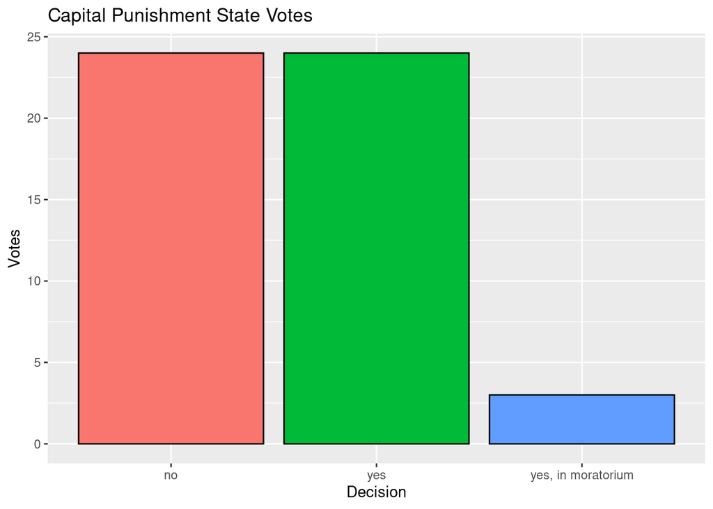

```r
ggplot(cap_punish, aes(x = dp2)) +
  geom_bar(aes(fill = dp2), color = "black") +
  labs(title = "Capital Punishment State Votes", x = "Decision", y = "Votes") +
  theme(legend.position = "none")
```

### Plot #2: Capital Punishment By Region of the U.S.

- Create a barplot for the variable `region`.
- Use `fill =` to shade each bar according to `dp2`.
- Change the `position =` to set each bar equal to 100%.
- Use `width =` to make the bars narrower than the default.
- Use `labs()` to add a title, axis labels, and a better legend label.
- Use `scale_fill_manual()` to choose a different color scheme for the plot.
- Use `theme()` to move the legend to the bottom of the plot instead of the right
- You may optionally add a subtitle, caption, or ggplot2 built-in theme to the plot.

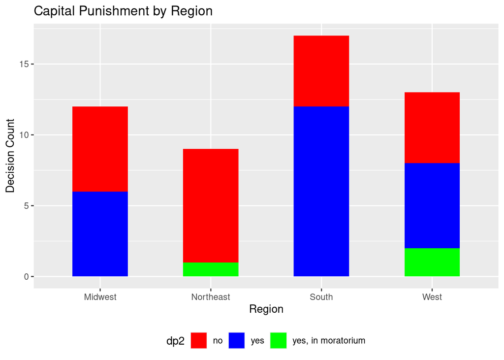

```r
ggplot(cap_punish, aes(x = region, fill = dp2)) +
  geom_bar(position = "stack", width = .5) +
  labs(title = "Capital Punishment by Region", x = "Region", y = "Decision Count") +
  scale_fill_manual(values = c("red", "blue", "green"))+
  theme(legend.position = "bottom")
```

### Plot #3: Number of Prisoners on Death Row

- Create a barplot for the total number of prisoners (y) in each year (x).
- Fill the bars using the variable `decade` and outline them all in black.
- Set the width of all the bars so there is no visible gap in between them.
- Scale the x-axis to include a tick mark at each decade (1970, 1980, etc).
- Scale the y axis so that it is numbered 0, 500, 1000, 1500, 2000, etc.
- Use `labs()` to add or change the title, axis labels, and legend label.
- Use `theme()` to do the following:
  - center your title
  - set the plot background to white or blank
  - set all axis tick marks to transparent or blank
  - set the major x-axis gridlines to transparent or blank
  - set the major y-axis gridlines to light gray
- You may optionally change the bar color scheme used in your plot

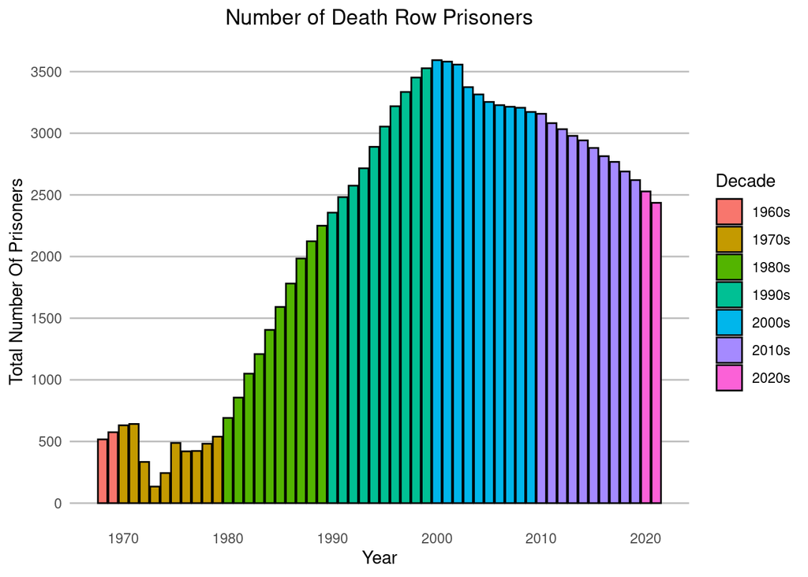

```r
ggplot(death_row_size, aes(x = year, y = total))+
  geom_col(aes(fill = decade), color = "black")+
  scale_x_continuous(n.breaks = 7) +
  scale_y_continuous(breaks = seq(0, 4000, by = 500)) +
  labs(title = "Number of Death Row Prisoners", x = "Year", y = "Total Number Of Prisoners") +
  scale_fill_discrete(name = "Decade") +
  theme(axis.ticks = element_blank(),
        panel.background = element_blank(),
        panel.grid.major.y = element_line(color = "grey"),
        panel.grid.major.x = element_blank(),
        plot.title = element_text(hjust = 0.5))
```

### Plot #4: Number of Executions Since 1976

- Create a violin plot for the variable `post1976` (use `y = 0`)
- Add a boxplot and set the width so it fits inside the violin plot
- Fill each plot with a color of your choice (be colorblind-aware)
- Scale the x-axis of the plot so that it counts in increments of 25
- Get rid of all y-axis markings/gridlines using `scale_y_continuous()`
- Add a title, x-axis label, and a caption to identify the large outlier
- Add the built-in theme `theme_linedraw()` or `theme_minimal` to the plot

Hint: You can use the `NULL` vector in functions like `scale_y_continuous()`

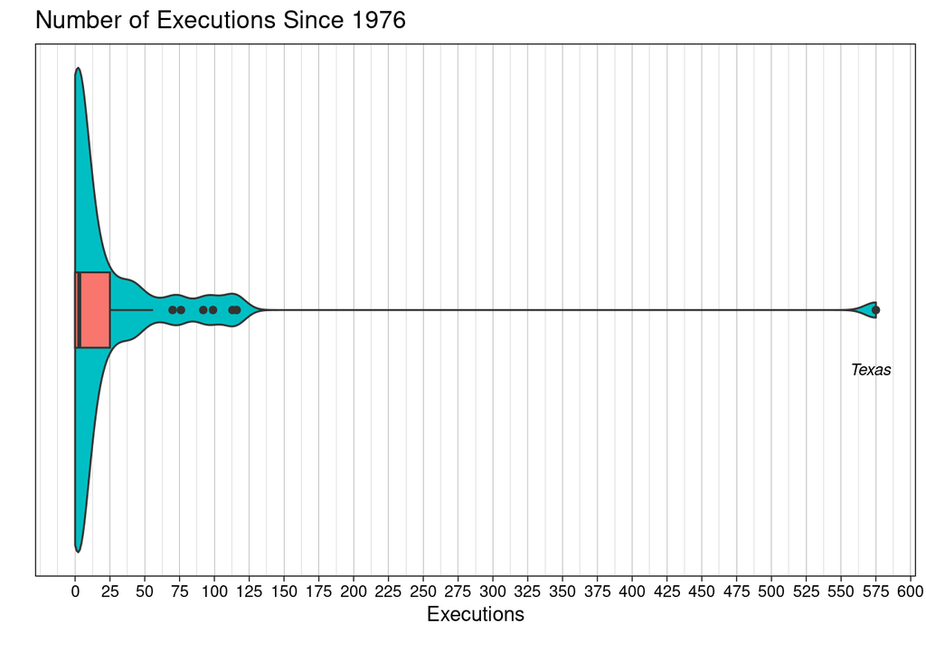

```r
ggplot(cap_punish, aes(x = post1976, y = 0)) +
  geom_violin(aes(fill = "red")) +
  geom_boxplot(aes(fill = "blue"), width = .14) +
  scale_x_continuous(breaks = seq(0, 600, by = 25)) +
  scale_y_continuous(breaks = NULL) +
  labs(title = "Number of Executions Since 1976", x = "Executions",
       y = "", caption = "Texas") +
  theme_linedraw() +
  theme(legend.position = "none",
        plot.caption = element_text(vjust = 80, hjust = .97, face = "italic"))
```

### Plot #5: Death Sentences in NC Since 1976

Create a time series plot of death sentences in North Carolina. Use three geometries on this plot: `geom_area()`, `geom_line()` and `geom_point()`. Use `geom_vline()` to add a vertical line for 2001. The significance of this year is that the General Assembly modified the death penalty statute in several ways, including giving prosecutors the discretion to *not* seek the death penalty in cases where it previously would have been mandatory. Format and label your plot in such a way that the information it conveys would be clear to the reader (i.e., the plot is reasonably stand-alone).

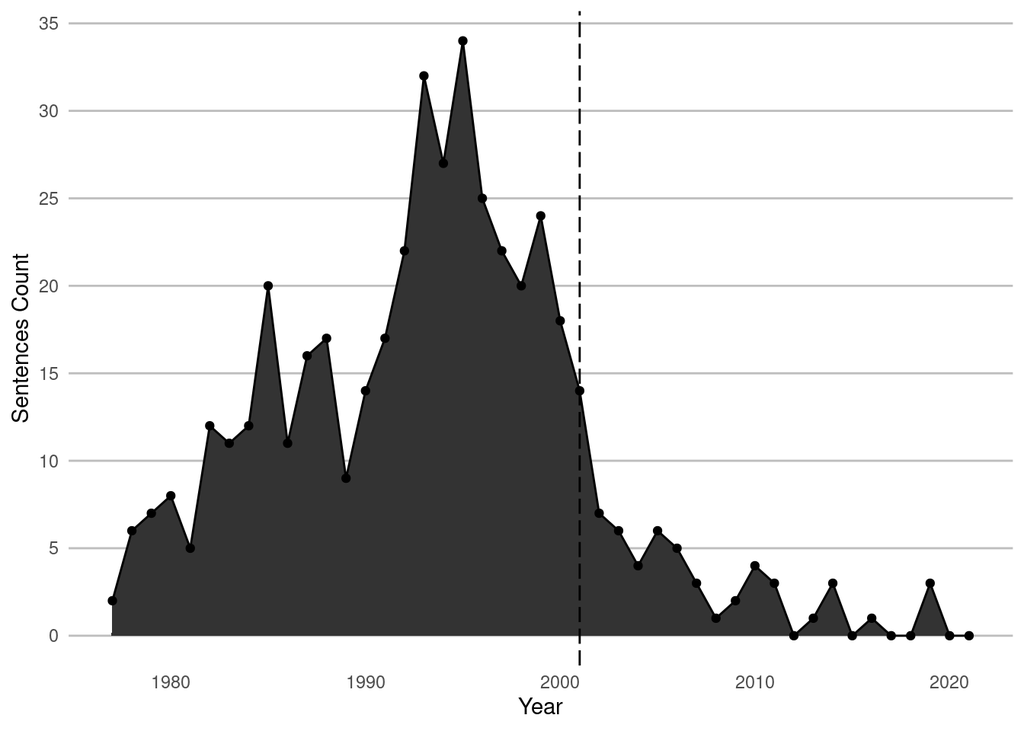

```r
ggplot(death_sentences_NC, aes(x = year, y = sentences)) +
  geom_area() +
  geom_line() +
  geom_point() +
  geom_vline(xintercept = 2001, linetype = "longdash") +
  labs(x = "Year", y = "Sentences Count") +
  scale_y_continuous(breaks = seq(0, 35, by = 5)) +
    theme(axis.ticks = element_blank(),
        panel.background = element_blank(),
        panel.grid.major.y = element_line(color = "grey"),
        panel.grid.major.x = element_blank(),
        plot.title = element_text(hjust = 0.5))
```

### Information Conveyed by Your Plots

List two pieces of information you can learn or comparisons you can make from each plot above.

#### Plot #1

- Item 1: The same amount of states voted in favor of as well as against capital punishment.
- Item 2: There were less than five states that voted in moratorium (not a complete vote in favor of captial punishment).

#### Plot #2

- Item 1: By region, the south had the most votes in favor of capital punishment.
- Item 2: The Northeast region had no reported votes in favor of capital punishment.

#### Plot #3

- Item 1: The year 2000 had the most reported death row prisoners from the 1960s to the 2020s
- Item 2: After 2000, the number of death row prisoners appears to show a steady decrease in number.

#### Plot #4

- Item 1: The majority of state executions were in between 0 and 25 after 1976
- Item 2: Texas provided a large outlier in the data. This may be due to its size and regional location.

#### Plot #5

- Item 1: After the sentences were modified sentence count stayed relatively low (around or below 5 and got as low as 0 in some years).
- Item 2: There was a spike in sentence count in the 1990s. This could provide the reason the law was changed due to its proximity to the line seen on the graph.